# Lithic data analysis of Jerimalai Square B

```r
# save plot
jhe_190mm_ggsave("figures/fig_8_Jeremalai-flake-core-cortex-phase.png", height = 190/2)
```

The code chunk below uses a Bayesian one-way ANOVA to investigate differences in chert flake cortex by depositional phase.

```r
myDataFrame <- data.frame(phase = flakes$phase, cortex = flakes$Cortex)
# remove flakes with no phase
myDataFrame <- myDataFrame[!is.na(myDataFrame$phase),]
yName = names(myDataFrame)[2] # cortex
xName = names(myDataFrame)[1] # phase
contrasts = list(
  list( c("1") ,  c("2") , compVal=0.0 , ROPE=c(-0.1,0.1) ) ,
  list( c("2")  , c("3") , compVal=0.0 , ROPE=c(-0.1,0.1)) ,
  list( c("3")  , c("4") , compVal=0.0 , ROPE=c(-0.1,0.1))  )
# Generate the MCMC chain:
  mcmcCoda_ANOVA = genMCMC_ANOVA(datFrm=myDataFrame , yName=yName , xName=xName ,
                      numSavedSteps=11000 , thinSteps=10
                      )
```

```
Calling 3 simulations using the parallel method...
Following the progress of chain 1 (the program will wait for all
chains to finish before continuing):
Welcome to JAGS 3.4.0 on Tue Nov 10 22:50:28 2015
JAGS is free software and comes with ABSOLUTELY NO WARRANTY
Loading module: basemod: ok
Loading module: bugs: ok
. . Reading data file data.txt
. Compiling model graph
   Graph Size: 5820
. Reading parameter file inits1.txt
. Initializing model
. Adapting 500
-------------------------------------------------| 500
++++++++++++++++++++++++++++++++++++++++++++++++++ 100%
Adaptation successful
. Updating 1000
-------------------------------------------------| 1000
************************************************** 100%
. . . . . . Updating 36670
-------------------------------------------------| 36650
************************************************** 100%
* 100%
. . . . Updating 0
. Deleting model
.
All chains have finished
Simulation complete.  Reading coda files...
Coda files loaded successfully
Finished running the simulation
```

```r
  # Get summary statistics of chain:
  summaryInfo_ANOVA = smryMCMC_ANOVA( mcmcCoda_ANOVA ,
                          datFrm=myDataFrame , xName=xName ,
                          contrasts=contrasts
                          )
  # #  Display posterior information (not easy to read unless using interactively):
#     plotMCMC_ANOVA( mcmcCoda_ANOVA ,
#               datFrm=myDataFrame , yName=yName , xName=xName ,
#               contrasts=contrasts  )
#
# subset summaryInfo to show HDI interval for interactions
HDI_intervals_for_interactions_f <- summaryInfo_ANOVA[c((nrow(summaryInfo_ANOVA)-length(contrasts)+1):nrow(summaryInfo_ANOVA)), c("HDIlow", "HDIhigh")]
kable(round(HDI_intervals_for_interactions_f,3), caption = "Highest density intervals (95%) for the posterior distributions of the interactions between phases and flake cortex")
```

Highest density intervals (95%) for the posterior distributions of the interactions between phases and flake cortex

|  | HDIlow | HDIhigh |
| --- | --- | --- |
| 1.v.2 | -0.804 | 2.151 |
| 2.v.3 | -1.550 | 1.007 |
| 3.v.4 | -2.031 | 0.132 |

The code chunk above produced results that indicate that the HDIs for all phases include zero, which we interpret as no credible difference. In the code chunk below we repeat the same investigation using a frequentist ANOVA.

```r
# ANOVA with Tukey's HSD
fit <- aov(cortex ~ as.factor(phase), myDataFrame)
fit_summary <-  summary(fit)
tuk <- TukeyHSD(fit)
# plot(tuk, las = 2, cex = 0.1)
kable(round(tuk$`as.factor(phase)`,3), caption = "Tukey's Honest Significant Difference for phase by phase comparisons of flake cortex")
```

Tukey’s Honest Significant Difference for phase by phase comparisons of flake cortex

|  | diff | lwr | upr | p adj |
| --- | --- | --- | --- | --- |
| 2-1 | -0.940 | -3.228 | 1.348 | 0.716 |
| 3-1 | -0.491 | -2.297 | 1.314 | 0.897 |
| 4-1 | 0.729 | -1.139 | 2.596 | 0.748 |
| 3-2 | 0.449 | -1.527 | 2.424 | 0.937 |
| 4-2 | 1.668 | -0.364 | 3.701 | 0.150 |
| 4-3 | 1.220 | -0.249 | 2.688 | 0.142 |

In the code chunk above we obtain the results of a frequentist ANOVA which returns a statistically nonsignificant result: F = 2.1550804, df = 3, p = 0.0912883. The Tukey’s Honest Significant Difference test shows confidence intervals on the differences between the means artefact masses of a phase. None of the interactions show a significant difference. We interpret this as evidence of overall no change in flake cortex.

In the two code chunks below we repeat the statistical tests above for core cortex.

```r
myDataFrame <- data.frame(phase = cores_mass$phase, cortex = cores_mass$Cortex)
myDataFrame <- myDataFrame[complete.cases(myDataFrame),] # omit NAs
yName = names(myDataFrame)[2] # cortex
xName = names(myDataFrame)[1] # phase
contrasts = list(
  list( c("1") ,  c("2") , compVal=0.0 , ROPE=c(-0.1,0.1) ) ,
  list( c("2")  , c("3") , compVal=0.0 , ROPE=c(-0.1,0.1)) ,
  list( c("3")  , c("4") , compVal=0.0 , ROPE=c(-0.1,0.1))
  )
# Generate the MCMC chain:
  mcmcCoda_ANOVA = genMCMC_ANOVA(datFrm=myDataFrame , yName=yName , xName=xName ,
                      numSavedSteps=11000 , thinSteps=10
                      )
```

```
Calling 3 simulations using the parallel method...
Following the progress of chain 1 (the program will wait for all
chains to finish before continuing):
Welcome to JAGS 3.4.0 on Tue Nov 10 22:52:20 2015
JAGS is free software and comes with ABSOLUTELY NO WARRANTY
Loading module: basemod: ok
Loading module: bugs: ok
. . Reading data file data.txt
. Compiling model graph
   Graph Size: 286
. Reading parameter file inits1.txt
. Initializing model
. Adapting 500
-------------------------------------------------| 500
++++++++++++++++++++++++++++++++++++++++++++++++++ 100%
Adaptation successful
. Updating 1000
-------------------------------------------------| 1000
************************************************** 100%
. . . . . . Updating 36670
-------------------------------------------------| 36650
************************************************** 100%
* 100%
. . . . Updating 0
. Deleting model
.
All chains have finished
Simulation complete.  Reading coda files...
Coda files loaded successfully
Finished running the simulation
```

```r
  # Get summary statistics of chain:
  summaryInfo_ANOVA = smryMCMC_ANOVA( mcmcCoda_ANOVA ,
                          datFrm=myDataFrame , xName=xName ,
                          contrasts=contrasts
                          )
  # #  Display posterior information (not easy to read unless using interactively):
#     plotMCMC_ANOVA( mcmcCoda_ANOVA ,
#               datFrm=myDataFrame , yName=yName , xName=xName ,
#               contrasts=contrasts  )
#
# subset summaryInfo to show HDI interval for interactions
 HDI_intervals_for_interactions_c <- summaryInfo_ANOVA[c((nrow(summaryInfo_ANOVA)-length(contrasts)+1):nrow(summaryInfo_ANOVA)), c("HDIlow", "HDIhigh")]
kable(round(HDI_intervals_for_interactions_c,3), caption = "Highest density intervals (95%) for the posterior distributions of the interactions between phases and core cortex")
```

Highest density intervals (95%) for the posterior distributions of the interactions between phases and core cortex

|  | HDIlow | HDIhigh |
| --- | --- | --- |
| 1.v.2 | -3.248 | 8.951 |
| 2.v.3 | -11.379 | 1.527 |
| 3.v.4 | -1.213 | 8.086 |

```r
# combine core and flake HDIs into one table
HDIs_for_cores_and_flakes <- round(cbind(HDI_intervals_for_interactions_c, HDI_intervals_for_interactions_f),3)
kable(HDIs_for_cores_and_flakes, caption = "Highest density intervals (95%) for the posterior distributions of the interactions between phases and core and flake cortex")
```

Highest density intervals (95%) for the posterior distributions of the interactions between phases and core and flake cortex

|  | HDIlow | HDIhigh | HDIlow | HDIhigh |
| --- | --- | --- | --- | --- |
| 1.v.2 | -3.248 | 8.951 | -0.804 | 2.151 |
| 2.v.3 | -11.379 | 1.527 | -1.550 | 1.007 |
| 3.v.4 | -1.213 | 8.086 | -2.031 | 0.132 |

The code chunk above produced results that indicate that the HDIs for all phases include zero, which we interpret as no credible difference. In the code chunk below we repeat the same investigation using a frequentist ANOVA.

```r
# ANOVA with Tukey's HSD
fit <- aov(cortex ~ as.factor(phase), myDataFrame)
fit_summary <-  summary(fit)
tuk <- TukeyHSD(fit)
# plot(tuk, las = 2, cex = 0.1)
kable(round(tuk$`as.factor(phase)`,3), caption = "Tukey's Honest Significant Difference for phase by phase comparisons of flake cortex")
```

|  | diff | lwr | upr | p adj |
| --- | --- | --- | --- | --- |
| 2-1 | -4.583 | -14.548 | 5.381 | 0.629 |
| 3-1 | 2.680 | -4.318 | 9.678 | 0.751 |
| 4-1 | -1.987 | -8.896 | 4.922 | 0.877 |
| 3-2 | 7.264 | -2.667 | 17.194 | 0.231 |
| 4-2 | 2.596 | -7.272 | 12.464 | 0.902 |
| 4-3 | -4.667 | -11.528 | 2.193 | 0.292 |

In the code chunk above we obtain the results of a frequentist ANOVA which returns a statistically nonsignificant result: F = 1.6785207, df = 3, p = 0.1752574. The Tukey’s Honest Significant Difference test shows confidence intervals on the differences between the means artefact masses of a phase. None of the interactions show a significant difference. We interpret this as evidence of overall no change in core cortex.

# Results: Core technology

This code draws a plot of differences in the mass of cores recovered from Jerimalai by core type.

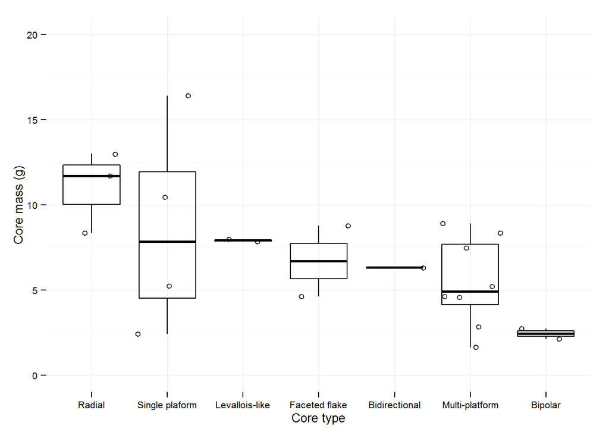

```r
sq_b_core_types <- core_types %>% filter(Square == "B")
sq_b_core_types$Type_long <- with(sq_b_core_types, ifelse(Type == "SPC", "Single plaform",
                                     ifelse(Type == "RC", "Radial",
                                      ifelse(Type == "BDC", "Bidirectional",
                                       ifelse(Type == "BiC", "Bipolar",
                                        ifelse(Type == "MPC", "Multi-platform",
                                         ifelse(Type == "LLC", "Levallois-like",
                                          ifelse(Type == "FFC", "Faceted flake", NA))))))) )
# plot
ggplot(sq_b_core_types, aes(reorder(Type_long, -Mass,  FUN=median), Mass)) +
   geom_jitter(alpha = 0.9, shape = 1) +
  geom_boxplot(alpha = 0.1, fill = "white", colour = "black") +
  ylim(0,20) +
  xlab("Core type") +
  ylab("Core mass (g)") +
  theme_minimal(base_size = 10)
```

```r
# save
jhe_190mm_ggsave("figures/fig_9_Jeremalai-core-by-type.png", height = 190/1.6)
```

The code chunk below computes the amount of cortex for each core type.

```r
core_cortex <- aggregate( X..Cortex ~ Type, data = sq_b_core_types, mean)
# what is the average amount of cortex for each core type?
core_cortex_means <- arrange(core_cortex, -X..Cortex)
names(core_cortex_means) <- c("Type", "Cortex percentage")
core_cortex_means[,2] <- round(core_cortex_means[,2],1)
```

The code chunk below computes the numbers of flake scars by each core type.

```r
core_scars <- sq_b_core_types %>%
  group_by(Type) %>%
  summarize(means = round(mean(Number.of.Scars, na.rm = TRUE),0),
            sds = round(sd(Number.of.Scars,  na.rm = TRUE)),0) %>%
  arrange(means)
```

# Results: Retouched artefacts

The code chunk below draws a plot showing locations of retouch on chert flakes by depositional unit at Jerimalai square B.

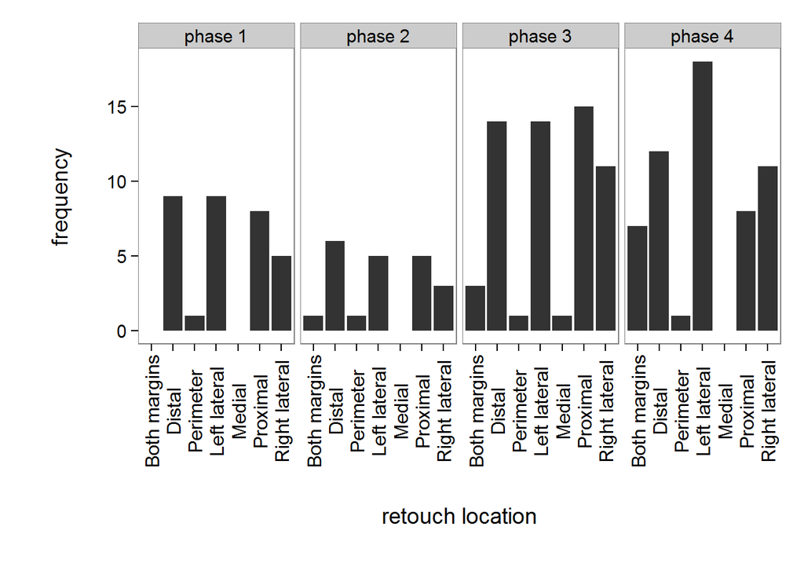

```r
# frequency of flakes with retouch per phase
rt <- flakes[flakes$Rtch == "Yes", ]
rt_tab <- t(data.frame(rt = aggregate(Retype ~ phase, rt, function(x) rt_count = length(x)), flakes =  aggregate(Retype ~ phase, flakes, function(x) fk_count = length(x))[,2] ))

# retouch locations
rt_loc <- data.frame(phase = rt$phase, rt_loc = rt$Retloc)
rt_loc <- rt_loc[!(is.na(rt_loc$phase)), ]
rt_sum <- as.data.frame.matrix(table(rt_loc))[,-1]
rt_sum$phase <- paste0("phase ", row.names(rt_sum))
colnames(rt_sum) <- c("Both margins", "Distal", "Perimeter", "Left lateral", "Medial", "Proximal", "Right lateral", "phase")
rt_sum_m <- melt(rt_sum)
# plot
ggplot(rt_sum_m, aes(variable, value)) +
  geom_bar(stat="identity") +
  theme(axis.text.x  = element_text(angle=90, vjust=0.5, size=12)) +
  ylab("frequency") +
  xlab("retouch location") +
  facet_wrap(~phase, ncol = 5)
```

```r
# save plot
jhe_190mm_ggsave("figures/fig_15_Jeremalai-flake-retouched-flake-location-phase.png", height = 190/1.6)
```

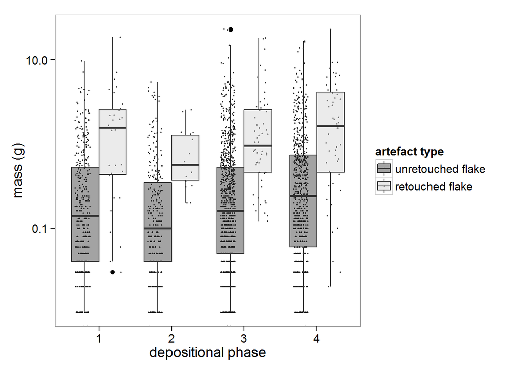

```r
flakes_retouch_size <- allchert %>%
                         filter(Artclas %in% c("flake", "retf")) %>%
                         filter(phase %in% 1:4) %>%
                         select(Artclas, Weight, Length, phase)

ggplot(flakes_retouch_size, aes( fill = Artclas, as.factor(phase), Weight)) +
  geom_point(aes(colour = Artclas), size = 0.5, alpha = 0.9, shape = 1,
             position=position_jitterdodge(dodge.width=0.9)) +
  geom_boxplot(alpha = 0.4) +
  scale_y_log10() +
  xlab('depositional phase') +
  ylab("mass (g)") +
  scale_fill_manual(name="artefact type",
                    labels=c("unretouched flake", "retouched flake"),
                    values = c("grey10", "grey80")) +
  scale_colour_manual(name="artefact type",
                    labels=c("unretouched flake", "retouched flake"),
                    values = c("grey10", "grey15"))
```

```r
# save plot
jhe_190mm_ggsave("figures/fig_16_Jeremalai-flake-retouchedflake-mass-phase.png", height = 190/1.6)
```

The code chunk below computes the tests for credible difference in retouch flake frequency by phase.

```r
rt_tab <- data.frame(rt_tab)
colnames(rt_tab) <- c("phase 1", "phase 2", "phase 3", "phase 4")
rt_tab <- rt_tab[-1,]
myDataFrame <- melt(as.matrix(rt_tab),  varnames=c("retouch", "phase"), value.name="Freq")
myDataFrame <- myDataFrame[complete.cases(myDataFrame),] # omit NAs
yName=names(myDataFrame)[3]   # Freq
x1Name=names(myDataFrame)[2]  # phase
x2Name=names(myDataFrame)[1]  # retouch
x1contrasts = list(
  list( c("phase 1") , c("phase 2") , compVal=0.0 , ROPE=c(-0.1,0.1) ) ,
  list( c("phase 2")  , c("phase 3") , compVal=0.0 , ROPE=c(-0.1,0.1)) ,
  list( c("phase 3")  , c("phase 4") , compVal=0.0 , ROPE=c(-0.1,0.1))
  )
numSavedSteps = 12000 # MCMC parameters
thinSteps = 10        # MCMC parameters

mcmcCoda = genMCMC_cont_table( datFrm=myDataFrame ,
                    yName=yName , x1Name=x1Name , x2Name=x2Name ,
                    numSavedSteps=numSavedSteps , thinSteps=thinSteps ,
                    )
```

```
Calling 3 simulations using the parallel method...
Following the progress of chain 1 (the program will wait for all
chains to finish before continuing):
Welcome to JAGS 3.4.0 on Tue Nov 10 22:52:42 2015
JAGS is free software and comes with ABSOLUTELY NO WARRANTY
Loading module: basemod: ok
Loading module: bugs: ok
. . Reading data file data.txt
. Compiling model graph
   Graph Size: 136

WARNING: Unused variable(s) in data table:
ySum

. Reading parameter file inits1.txt
. Initializing model
. Adapting 1000
-------------------------------------------------| 1000
++++++++++++++++++++++++++++++++++++++++++++++++++ 100%
Adaptation successful
. Updating 2000
-------------------------------------------------| 2000
************************************************** 100%
. . . . . . . . . . . . Failed to set trace monitor for delta
Node not found
. Updating 40000
-------------------------------------------------| 40000
************************************************** 100%
. . . . Updating 0
. Deleting model
.
All chains have finished
Simulation complete.  Reading coda files...
Coda files loaded successfully
Finished running the simulation
```

```r
# Get summary statistics of chain:
summaryInfo = smryMCMC_cont_table( mcmcCoda ,
                        datFrm=myDataFrame , x1Name=x1Name , x2Name=x2Name ,
                        x1contrasts=x1contrasts
                         )

# # #  Display posterior information (not easy to read unless using interactively):
#     plotMCMC_cont_table( mcmcCoda ,
#               datFrm=myDataFrame , yName=yName , x1Name=x1Name ,
#                x2Name=x2Name ,
#               x1contrasts=x1contrasts  )

# table of retouch artefact counts
kable(rt_tab, caption = "Table of frequencies of retouched flakes by phase")
```

Table of frequencies of retouched flakes by phase

|  | phase 1 | phase 2 | phase 3 | phase 4 |
| --- | --- | --- | --- | --- |
| rt.Retype | 32 | 21 | 59 | 57 |
| flakes | 475 | 371 | 1130 | 915 |

```r
# subset summaryInfo to show HDI interval for interactions
 HDI_intervals_for_interactions_fr <- summaryInfo_ANOVA[c((nrow(summaryInfo_ANOVA)-length(contrasts)+1):nrow(summaryInfo_ANOVA)), c("HDIlow", "HDIhigh")]
kable(round(HDI_intervals_for_interactions_fr,3), caption = "Highest density intervals (95%) for the posterior distributions of the interactions between phases and retouched flake frequency.")
```

Highest density intervals (95%) for the posterior distributions of the interactions between phases and retouched flake frequency.

|  | HDIlow | HDIhigh |
| --- | --- | --- |
| 1.v.2 | -3.248 | 8.951 |
| 2.v.3 | -11.379 | 1.527 |
| 3.v.4 | -1.213 | 8.086 |

```r
chert_artefacts_retouch_nhst <- assocstats(as.matrix(rt_tab))
```

The code chunk above returns a chi-squared value of 1.5586223 and a p-value of 0.6688079, indicating a nonsignficant difference in frequencies of breakage classes by phase. The Cramer’s V value of 0.0225689 indicates that the effect size is extremely small. We interpret this result to mean that there is no substantial significance in the differences in frequencies of retouched flakes by phase.

The code chunk below investigates changes in the length of the retouched margin of artefacts over time.

```r
rt_len <- data.frame(phase = rt$phase, rt_len = rt$Retlen)
# omit NAs
rt_len <- rt_len[!(is.na(rt_len$rt_len)), ]
# get mean lengths
mean_lengths <- aggregate(rt_len ~ phase, rt_len, mean)
# do bayesian ANOVA
myDataFrame <- rt_len
myDataFrame <- myDataFrame[complete.cases(myDataFrame),] # omit NAs
yName = names(myDataFrame)[2] # retouch length
xName = names(myDataFrame)[1] # phase
contrasts = list(
  list( c("1") ,  c("2") , compVal=0.0 , ROPE=c(-0.1,0.1) ) ,
  list( c("2")  , c("3") , compVal=0.0 , ROPE=c(-0.1,0.1)) ,
  list( c("3")  , c("4") , compVal=0.0 , ROPE=c(-0.1,0.1))  )
# Generate the MCMC chain:
  mcmcCoda_ANOVA = genMCMC_ANOVA(datFrm=myDataFrame , yName=yName , xName=xName ,
                      numSavedSteps=11000 , thinSteps=10
                      )
```

```
Calling 3 simulations using the parallel method...
Following the progress of chain 1 (the program will wait for all
chains to finish before continuing):
Welcome to JAGS 3.4.0 on Tue Nov 10 22:52:54 2015
JAGS is free software and comes with ABSOLUTELY NO WARRANTY
Loading module: basemod: ok
Loading module: bugs: ok
. . Reading data file data.txt
. Compiling model graph
   Graph Size: 214
. Reading parameter file inits1.txt
. Initializing model
. Adapting 500
-------------------------------------------------| 500
++++++++++++++++++++++++++++++++++++++++++++++++++ 100%
Adaptation successful
. Updating 1000
-------------------------------------------------| 1000
************************************************** 100%
. . . . . . Updating 36670
-------------------------------------------------| 36650
************************************************** 100%
* 100%
. . . . Updating 0
. Deleting model
.
All chains have finished
Simulation complete.  Reading coda files...
Coda files loaded successfully
Finished running the simulation
```

```r
  # Get summary statistics of chain:
  summaryInfo_ANOVA = smryMCMC_ANOVA( mcmcCoda_ANOVA ,
                          datFrm=myDataFrame , xName=xName ,
                          contrasts=contrasts
                          )
  # #  Display posterior information (not easy to read unless using interactively):
#     plotMCMC_ANOVA( mcmcCoda_ANOVA ,
#               datFrm=myDataFrame , yName=yName , xName=xName ,
#               contrasts=contrasts  )
#
# subset summaryInfo to show HDI interval for interactions
 HDI_intervals_for_interactions_l <- summaryInfo_ANOVA[c((nrow(summaryInfo_ANOVA)-length(contrasts)+1):nrow(summaryInfo_ANOVA)), c("HDIlow", "HDIhigh")]
kable(round(HDI_intervals_for_interactions_l ,3), caption = "Highest density intervals (95%) for the posterior distributions of the interactions between phases and retouch length")
```

Highest density intervals (95%) for the posterior distributions of the interactions between phases and retouch length

|  | HDIlow | HDIhigh |
| --- | --- | --- |
| 1.v.2 | -2.885 | 6.741 |
| 2.v.3 | -8.396 | 2.254 |
| 3.v.4 | -3.817 | 6.483 |

```r
# combine retouch freq and length into one table
HDIs_flake_retouch_freq_and_length <- round(cbind(HDI_intervals_for_interactions_fr, HDI_intervals_for_interactions_l),3)
kable(HDIs_flake_retouch_freq_and_length, caption = "Highest density intervals (95%) for the posterior distributions of the interactions between phases and retouch frequency and length")
```

Highest density intervals (95%) for the posterior distributions of the interactions between phases and retouch frequency and length

|  | HDIlow | HDIhigh | HDIlow | HDIhigh |
| --- | --- | --- | --- | --- |
| 1.v.2 | -3.248 | 8.951 | -2.885 | 6.741 |
| 2.v.3 | -11.379 | 1.527 | -8.396 | 2.254 |
| 3.v.4 | -1.213 | 8.086 | -3.817 | 6.483 |

The results of the code chunk above show that the HDIs for all interactions include zero. This indicates no credible difference in retouch length by phase.

The code chunk below repeats this analysis using a frequentist test.

```r
# ANOVA with Tukey's HSD
fit <- aov(rt_len ~ as.factor(phase), myDataFrame)
fit_summary <-  summary(fit)
tuk <- TukeyHSD(fit)
# plot(tuk, las = 2, cex = 0.1)
kable(round(tuk$`as.factor(phase)`,3), caption = "Tukey's Honest Significant Difference for phase by phase comparisons of flake retouch length")
```

Tukey’s Honest Significant Difference for phase by phase comparisons of flake retouch length

|  | diff | lwr | upr | p adj |
| --- | --- | --- | --- | --- |
| 2-1 | -2.956 | -11.071 | 5.158 | 0.775 |
| 3-1 | 2.043 | -6.320 | 10.405 | 0.919 |
| 4-1 | 0.210 | -8.293 | 8.713 | 1.000 |
| 3-2 | 4.999 | -4.032 | 14.029 | 0.472 |
| 4-2 | 3.166 | -5.995 | 12.328 | 0.802 |
| 4-3 | -1.833 | -11.214 | 7.549 | 0.956 |

In the code chunk above we obtain the results of a frequentist ANOVA which returns a statistically nonsignificant result: F = 0.7300247, df = 3, p = 0.5369313. The Tukey’s Honest Significant Difference test shows confidence intervals on the differences between the means artefact retouch length of a phase. None of the interactions show a significant difference. We interpret this as evidence of overall no change in flake retouch length.

```r
# Bayesian t-test of the mass of all retouched vs all unretouched flakes
# flakes_retouch_size_t_test <- BESTmcmc(flakes_retouch_size[flakes_retouch_size$Artclas == "flake", ]$Weight, flakes_retouch_size[flakes_retouch_size$Artclas == "retf", ]$Weight)
```

In the code chunk below we perform a frequentist t-test on flake mass of retouched and non-retouched flakes.

```r
retouch_nonretouch_flake_mass_nhst <- t.test(flakes_retouch_size[flakes_retouch_size$Artclas == "flake", ]$Weight, flakes_retouch_size[flakes_retouch_size$Artclas == "retf", ]$Weight)
```

The code chunk above returns the result of the frequentist t-test as follows: t = -6.1886492, df = 158.102378 and p = 5.000649310^{-9}.

The code chunk below makes a table the summarises retouch indices for retouched pieces recovered from Jerimalai. GIUR = Geometric Index of Unifacial Retouch, II = Index of Invasiveness, % = percent of perimeter with retouch

```r
retouch_indices[is.na(retouch_indices)] <- 0
retouch_indices$GIUR <- with(retouch_indices, t1/T1 + t2/T2 + t3/T3)/3
retouch_indices$perimeter_perc <- with(retouch_indices, length/perimeter * 100)
retouch_indices$II <- with(retouch_indices, ((X0.5 * 0.5) + (X1 * 1))/16)
# get mean and standard deviation for each index
retouch_indices_subset <- retouch_indices %>% select(GIUR, perimeter_perc, II)
# sweep over the columns to compute mean and standard deviation
retouch_indices_means <- data.frame(t(round(apply(retouch_indices_subset, 2, mean, na.rm = TRUE),2)))
retouch_indices_sds <- data.frame(t(round(apply(retouch_indices_subset, 2, sd, na.rm = TRUE),2)))
# make table
retouch_table <- retouch_indices %>%
  select(Square, Spit, Type, GIUR, II, perimeter_perc)
# do some rounding
retouch_table[,4:6] <- apply(retouch_table[,4:6], 2, round, 2)
# have a look
retouch_table <- arrange(retouch_table, Spit)
retouch_table$Phase <- makephases(retouch_table$Spit)
retouch_table  <- retouch_table[, c(1,2,7,3:6)]
# write the table to a csv file so we can put it in the word doc
write.csv(retouch_table, file = 'retouch_table.csv', row.names = FALSE)
kable(retouch_table, caption = "Summary of retouch indices for retouched pieces recovered from Jerimalai. GIUR = Geometric Index of Unifacial Retouch, II = Index of Invasiveness, % = percent of perimeter with retouch")
```

Summary of retouch indices for retouched pieces recovered from Jerimalai. GIUR = Geometric Index of Unifacial Retouch, II = Index of Invasiveness, % = percent of perimeter with retouch

| Square | Spit | Phase | Type | GIUR | II | perimeter_perc |
| --- | --- | --- | --- | --- | --- | --- |
| B | 3 | 4 | Ventral Side | NaN | 0.16 | 44.44 |
| B | 3 | 4 | Side and End | 0.42 | 0.16 | 28.70 |
| B | 4 | 4 | Double side and end (steep edged) | 0.83 | 0.28 | 50.00 |
| B | 4 | 4 | Double Side | 0.85 | 0.34 | 33.04 |
| B | 5 | 4 | Side Ventral | NaN | 0.06 | 11.94 |
| B | 10 | 4 | Side | 0.37 | 0.09 | 18.66 |
| B | 10 | 4 | End | 0.46 | 0.03 | 11.80 |
| B | 12 | 4 | Drill? | 0.55 | 0.19 | 43.10 |
| B | 14 | 4 | Notch | 0.62 | 0.09 | 20.00 |
| B | 19 | 4 | Denticulate | 0.19 | 0.16 | 27.68 |
| B | 22 | 3 | Notch (Ventral) | NaN | 0.09 | 40.69 |
| B | 25 | 3 | Bifacial End | 0.37 | 0.09 | 17.36 |
| B | 34 | 3 | Side and End (Alternating bifacial) | 0.38 | 0.12 | 28.23 |
| B | 38 | 3 | Notch (Ventral) | NaN | 0.06 | 14.59 |
| B | 39 | 3 | Concave Bifacial side and end | 0.80 | 0.56 | 60.15 |
| B | 40 | 2 | Side | 0.26 | 0.09 | 21.31 |
| A | 43 | 2 | Bec | 0.52 | 0.16 | 29.51 |

The retouch intensity can be summarised with the following metrics: GIUR = 0.51 +/- 0.21 perimeter = 29.48 +/- 14.09% II = 0.16 +/- 0.13

# Results: Technological types

This code makes the table “Summary of counts and classes. Counts refers to the count of spits in each depositional phase containing a given class.”

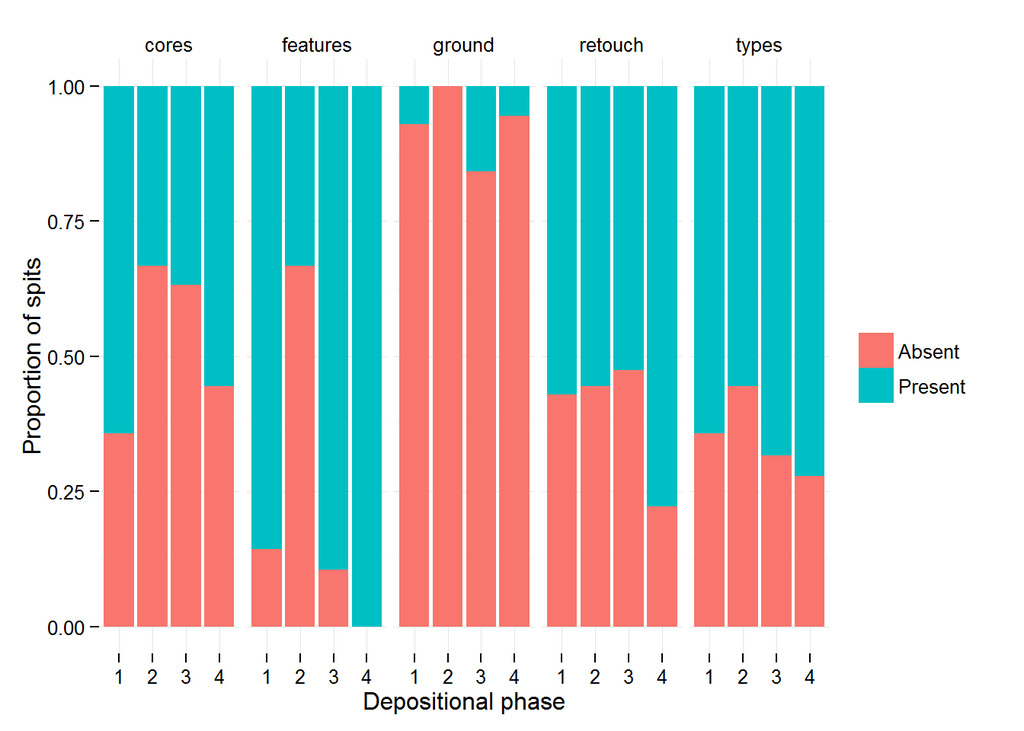

```r
# all

# combine

techno <- data.frame(cores, types, retouch, features, ground,  stringsAsFactors = FALSE)
# remove extra Spit cols (is those called 'Spit.1' etc)
techno <- techno[,-grep("Spit\\.", colnames(techno)) ]
# put depths on
techno$depth <- depths$Depth.bs..m[match(techno$Spit,depths$Spit.no)]
# put phases on
techno$phase <- flakes$phase[match(techno$Spit,flakes$Spit)]

techno[] <- lapply(techno, as.character) # change factor to character
techno[techno == 'x'] <-  1 # replace x with 1
techno[] <- lapply(techno, as.numeric) # change char to num
# get row sums
rs <- rowSums(techno[,2:32], na.rm = TRUE )
# get row sums by group
rs_phase <- data.frame(rs, phase = techno$phase)
# % that have a type present
# phases with no types at all
check <- rs_phase[rs_phase$rs == 0,]
# set 1 or above to 1
rs_phase$rs <- ifelse(rs_phase$rs == 0, 0, 1)
check <- aggregate(rs ~ phase, rs_phase[rs_phase$rs == 0,], length) # counts
check <- t(apply(table(rs_phase), 2, function(x) x/sum(x))) # props
# just three spits with zero types... let's do it by class

## cores ##
# put depths on
cores$depth <- depths$Depth.bs..m[match(cores$Spit,depths$Spit.no)]
# put groups on
cores$phase <- flakes$phase[match(cores$Spit,flakes$Spit)]
cores[] <- lapply(cores, as.character) # change factor to character
cores[cores == 'x'] <-  1 # replace x with 1
cores[] <- lapply(cores, as.numeric) # change char to num
# get row sums
rs <- rowSums(cores[,2:(ncol(cores)-2)], na.rm = TRUE )
# get row sums by phase
rs_phase <- data.frame(rs, group = cores$phase)
# % that have a type present
# groups with no types at all
check <- rs_phase[rs_phase$rs == 0,]
# set any non-zero to 1
rs_phase$rs <- ifelse(rs_phase$rs != 0, 1, rs_phase$rs)
# yes, more with zero here...
dc_core <- data.frame(t(apply(table(rs_phase), 2, function(x) x/sum(x))))
dc_core <- prop.table(as.matrix(dc_core), 1)

## types ##
# put depths on
types$depth <- depths$Depth.bs..m[match(types$Spit,depths$Spit.no)]
# put groups on
types$phase <- flakes$phase[match(types$Spit,flakes$Spit)]
types[] <- lapply(types, as.character) # change factor to character
types[types == 'x'] <-  1 # replace x with 1
types[] <- lapply(types, as.numeric) # change char to num
# get row sums
rs <- rowSums(types[,2:(ncol(types)-2)], na.rm = TRUE )
# get row sums by group
rs_phase <- data.frame(rs, phase = types$phase)
# % that have a type present
# groups with no types at all
check <- rs_phase[rs_phase$rs == 0,]
# set any non-zero to 1
rs_phase$rs <- ifelse(rs_phase$rs != 0, 1, rs_phase$rs)
# yes, more with zero here...
dc_types <- data.frame(t(apply(table(rs_phase), 2, function(x) x/sum(x))))
dc_types <- prop.table(as.matrix(dc_types), 1)

## retouch ##
# put depths on
retouch$depth <- depths$Depth.bs..m[match(retouch$Spit,depths$Spit.no)]
# put groups on
retouch$phase <- flakes$phase[match(retouch$Spit,flakes$Spit)]
retouch[] <- lapply(retouch, as.character) # change factor to character
retouch[retouch == 'x'] <-  1 # replace x with 1
retouch[] <- lapply(retouch, as.numeric) # change char to num
# get row sums
rs <- rowSums(retouch[,2:(ncol(retouch)-2)], na.rm = TRUE )
# get row sums by group
rs_phase <- data.frame(rs, phase = retouch$phase)
# % that have a type present
# groups with no types at all
check <- rs_phase[rs_phase$rs == 0,]
# set any non-zero to 1
rs_phase$rs <- ifelse(rs_phase$rs != 0, 1, rs_phase$rs)
# yes, more with zero here...
dc_retouch <- data.frame(t(apply(table(rs_phase), 2, function(x) x/sum(x))))
dc_retouch <- prop.table(as.matrix(dc_retouch), 1)

## features ##
# put depths on
features$depth <- depths$Depth.bs..m[match(features$Spit,depths$Spit.no)]
# put groups on
features$phase <- flakes$phase[match(features$Spit,flakes$Spit)]
features[] <- lapply(features, as.character) # change factor to character
features[features == 'x'] <-  1 # replace x with 1
features[] <- lapply(features, as.numeric) # change char to num
# get row sums
rs <- rowSums(features[,2:(ncol(features)-2)], na.rm = TRUE )
# get row sums by group
rs_phase <- data.frame(rs, phase = features$phase)
# % that have a type present
# groups with no types at all
check <- rs_phase[rs_phase$rs == 0,]
# set any non-zero to 1
rs_phase$rs <- ifelse(rs_phase$rs != 0, 1, rs_phase$rs)
# yes, more with zero here...
dc_feat <- data.frame(t(apply(table(rs_phase), 2, function(x) x/sum(x))))
dc_feat <- prop.table(as.matrix(dc_feat), 1)

## ground ##
# put depths on
ground$depth <- depths$Depth.bs..m[match(ground$Spit,depths$Spit.no)]
# put phases on
ground$phase <- flakes$phase[match(ground$Spit,flakes$Spit)]
ground[] <- lapply(ground, as.character) # change factor to character
ground[ground == 'x'] <-  1 # replace x with 1
ground[] <- lapply(ground, as.numeric) # change char to num
# get row sums
rs <- rowSums(ground[,2:(ncol(ground)-2)], na.rm = TRUE )
# get row sums by phase
rs_phase <- data.frame(rs, phase = ground$phase)
# % that have a type present
# phases with no types at all
check <- rs_phase[rs_phase$rs == 0,]
# set any non-zero to 1
rs_phase$rs <- ifelse(rs_phase$rs != 0, 1, rs_phase$rs)
# yes, more with zero here...
dc_gr <- data.frame(t(apply(table(rs_phase), 2, function(x) x/sum(x))))
dc_gr <- prop.table(as.matrix(dc_gr), 1)

# put them together
lst <- list(cores = dc_core,  retouch = dc_retouch, types = dc_types, features = dc_feat,  ground = dc_gr)
df <- ldply(lst, data.frame)
df$phase <- rep(seq_along(unique(na.omit(flakes$phase))), length(lst))

# plot proportion of spits having a techno-type present
df_m <- melt(df, id.var = c('phase', '.id'))
df_m$variable <- ifelse(df_m$variable == 'X0', 'Absent', 'Present')
ggplot(df_m, aes(as.factor(phase), value, fill = variable)) +
  geom_bar(stat="identity") +
  facet_grid(. ~ .id) +
  theme_minimal() +
  xlab("Depositional phase") +
  ylab("Proportion of spits") +
  scale_fill_discrete(name="")
```

```r
# now we can see, let's explore some of the minor patterns...
# what are the counts of each class in each phase?

# more about features
l <- lapply(features[,2:(ncol(features)-2)], function(i)  aggregate( i ~ phase, features, sum, na.rm = TRUE))
df <- do.call(rbind.data.frame, l)
df$name <- unlist(lapply(1:length(l), function(i) rep(names(l)[i], nrow(l[[i]]))))
feat <- dcast(phase ~ name, value.var = 'i', data = df)

# more about ground
l <- lapply(ground[,2:(ncol(ground)-2)], function(i)  aggregate( i ~ phase, ground, sum, na.rm = TRUE))
df <- do.call(rbind.data.frame, l)
df$name <- unlist(lapply(1:length(l), function(i) rep(names(l)[i], nrow(l[[i]]))))
grou <- dcast(phase ~ name, value.var = 'i', data = df)

# more about retouch
l <- lapply(retouch[,2:(ncol(retouch)-2)], function(i)  aggregate( i ~ phase, retouch, sum, na.rm = TRUE))
df <- do.call(rbind.data.frame, l)
df$name <- unlist(lapply(1:length(l), function(i) rep(names(l)[i], nrow(l[[i]]))))
reto <- dcast(phase ~ name, value.var = 'i', data = df)

# more about types
l <- lapply(types[,2:(ncol(types)-2)], function(i)  aggregate( i ~ phase, types, sum, na.rm = TRUE))
df <- do.call(rbind.data.frame, l)
df$name <- unlist(lapply(1:length(l), function(i) rep(names(l)[i], nrow(l[[i]]))))
type <- dcast(phase ~ name, value.var = 'i', data = df)

# more about cores
l <- lapply(cores[,2:(ncol(cores)-2)], function(i)  aggregate( i ~ phase, cores, sum, na.rm = TRUE))
df <- do.call(rbind.data.frame, l)
df$name <- unlist(lapply(1:length(l), function(i) rep(names(l)[i], nrow(l[[i]]))))
core <- dcast(phase ~ name, value.var = 'i', data = df)

# obsidian?
all$phase <- makephases(all$Spit)
obsidian <- table(data.frame(phase = all$phase, rm = all$Material))

# summary table of all techno-types. This will give a count of spits
# in each phase that contain at least one artefact in the category.
summaryt <- (t(cbind(
  ddply(retouch[,2:(ncol(retouch))], "phase", numcolwise(sum, na.rm = TRUE)),
  ddply(features[,2:(ncol(features))], "phase", numcolwise(sum, na.rm = TRUE)),
  ddply(ground[,2:(ncol(ground))], "phase", numcolwise(sum, na.rm = TRUE)),
  ddply(types[,2:(ncol(types))], "phase", numcolwise(sum, na.rm = TRUE)),
  ddply(cores[,2:(ncol(cores))], "phase", numcolwise(sum, na.rm = TRUE))
)))
summaryt <- summaryt[!(row.names(summaryt) %in% c("depth", "phase")),]
# compute proportions so we have the proportion of spits in each phase
# that contains at least one of each class.
spits_per_phase <- aggregate(Spit ~ phase, data = cores, length)
summaryt_props <- data.frame(round(t(t(summaryt) / spits_per_phase$Spit),2))
names(summaryt_props) <- c( "phase 1", "phase 2", "phase 3", "phase 4")
# write table to csv to put into word doc
write.csv(summaryt_props, "techno_types_table.csv")
kable(summaryt_props, caption = "Summary of proportions and classes. Proportions refers to the proportion of spits in each depositional phase containing a given class")
```

Summary of proportions and classes. Proportions refers to the proportion of spits in each depositional phase containing a given class

|  | phase 1 | phase 2 | phase 3 | phase 4 | NA |
| --- | --- | --- | --- | --- | --- |
| Distal | 0.36 | 0.11 | 0.11 | 0.56 | 0.00 |
| Lateral | 0.22 | 0.11 | 0.22 | 0.57 | 0.00 |
| Notched | 0.00 | 0.00 | 0.21 | 0.67 | 0.00 |
| Lateral.and.Distal | 0.11 | 0.07 | 0.00 | 0.05 | 0.00 |
| Double.Side.and.End | 0.14 | 0.11 | 0.05 | 0.22 | 0.00 |
| Denticulated | 0.00 | 0.00 | 0.06 | 0.07 | 0.00 |
| Notched.Lateral.and.Distal | 0.00 | 0.06 | 0.00 | 0.00 | 0.00 |
| Drill.Like.Retouch…Edge.Damage | 0.00 | 0.00 | 0.00 | 0.11 | 0.00 |
| Old.Ventral.Suface.on.Dorsal…Faceted.Platform | 0.64 | 0.11 | 0.53 | 0.39 | 0.07 |
| Platform.Faceting | 1.33 | 0.16 | 0.89 | 1.21 | 0.22 |
| Flake.With.Old.Ventral.on.Dorsal | 0.00 | 0.00 | 0.14 | 0.89 | 0.00 |
| Truncated.Flake | 0.00 | 0.00 | 0.11 | 0.00 | 0.00 |
| Flakes.With.Gloss | 0.00 | 0.00 | 0.05 | 0.17 | 0.00 |
| Possible.Ground.Flake..Axe.Flake.. | 0.11 | 0.00 | 0.00 | 0.00 | 0.00 |
| Striated.haematite | 0.00 | 0.00 | 0.21 | 0.11 | 0.00 |
| Microblade | 0.22 | 0.07 | 0.78 | 0.11 | 0.00 |
| Levallois.Like.Flake | 0.14 | 0.00 | 0.11 | 0.00 | 0.00 |
| Burin.Spall | 0.22 | 0.05 | 0.00 | 0.29 | 0.00 |
| Faceted.Point | 0.16 | 0.00 | 0.00 | 0.00 | 0.00 |
| Bipolar.Flake | 0.00 | 0.07 | 0.22 | 0.21 | 0.00 |
| Eclat.Debordant | 0.00 | 0.11 | 0.21 | 0.00 | 0.00 |
| Cortical.Flake | 0.22 | 0.00 | 0.06 | 0.21 | 0.00 |
| Redirecting.Flake | 0.05 | 0.06 | 0.36 | 1.00 | 0.00 |
| Chopper.Anvil | 0.00 | 0.07 | 0.00 | 0.05 | 0.00 |
| Semi.Discoidal | 0.07 | 0.11 | 0.00 | 0.11 | 0.00 |
| Faceted.Radial…Levallois | 0.44 | 0.00 | 0.06 | 0.21 | 0.00 |
| Truncated.Faceted.Flake | 0.21 | 0.00 | 0.07 | 0.11 | 0.00 |
| Bipolar | 0.11 | 0.00 | 0.11 | 0.21 | 0.00 |
| Bidirectional | 0.07 | 0.11 | 0.05 | 0.11 | 0.00 |
| Single.Platform | 0.22 | 0.00 | 0.06 | 0.29 | 0.00 |
| Mulitplatform | 0.21 | 0.06 | 0.21 | 0.44 | 0.00 |

# Colophon

```r
# what other pieces of software?
needs <- needs()
c(needs$depends$SystemRequirements[needs$depends$SystemRequirements != "NULL"], needs$imports$SystemRequirements[needs$imports$SystemRequirements != "NULL"])
```

```
[1] "zlib headers and library. OpenSSL headers and\nlibrary. LibSSH2 (optional on non-Windows) to enable the SSH\ntransport."
[2] "JAGS (http://mcmc-jags.sourceforge.net)"
[3] "JAGS 4.x.y"
[4] "pandoc (>= 1.12.3) -\nhttp://johnmacfarlane.net/pandoc"
[5] "Package vignettes based on R Markdown v2 require\nPandoc (http://pandoc.org). The function rst2pdf() and\nvignettes based on reStructuredText require rst2pdf\n(https://github.com/rst2pdf/rst2pdf)."
[6] "JAGS (http://mcmc-jags.sourceforge.net)"
[7] "ICU4C (>= 50, optional)"
```

```r
# what commit is this file at?
repo <- repository(path = "../")
last_commit <- commits(repo)[[1]]
```

The current git commit of this file is 045cf02bb03e002c6ca068f591406af97a63797b, which is on the master branch and was made by Ben Marwick on 2016-01-20 17:00:05. The current commit message is “update dockerfile with no-cache”.